# Lab9_Tessa_Mnist_DenseNeuralNetworks_TensorflowKeras

### -----------------------------------------------------------------------------------------------

### - **Name**: Tessa Ayvazoglu

### - **ID** : 8686601

### - **Date**: 17/03/2024

### ------------------------------------------------------------------------------------------------

### - **Program**: CSCN8010-24W-Sec1to2-Foundations of Machine Learning

### - **Lab 8 & Lab9** - MNIST Classification with Dense Neural Networks (using Tensorflow) & Avoiding Overfitting by Saving a Model

### ------------------------------------------------------------------------------------------------

## Load the Libraries

```python
# Load the libraries
from keras.layers import Dense, Input, Dropout, BatchNormalization
from sklearn.model_selection import train_test_split
from keras.callbacks import EarlyStopping
import matplotlib.pyplot as plt
import keras as ke
import tensorflow as tf
import os
import numpy as np
import sklearn.metrics as skm
import seaborn as sns
from sklearn.metrics import accuracy_score, precision_score, recall_score, f1_score, confusion_matrix, classification_report, roc_curve, auc, roc_auc_score
from tensorflow.keras.datasets import fashion_mnist
```

## Load and Preprocess the Fashion MNIST Dataset

```python
# Load and preprocess the Fashion MNIST dataset
(train_x, train_y), (test_x, test_y) = fashion_mnist.load_data()
train_x = train_x / 255
test_x = test_x / 255
train_x = train_x.reshape(-1, 784)
test_x = test_x.reshape(-1, 784)
train_x, val_x, train_y, val_y = train_test_split(train_x, train_y, test_size=0.2)

# Define the labels dictionary
labels = {0: "T-shirt/top", 1: "Trouser", 2: "Pullover", 3: "Dress", 4: "Coat",
          5: "Sandal", 6: "Shirt", 7: "Sneaker", 8: "Bag", 9: "Ankle boot"}
```

## Define a Function to Plot Sample Images

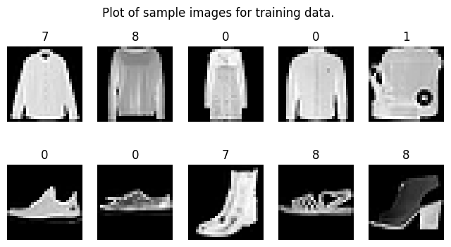

```
Shape of train_x: (48000, 784)
Shape of test_x: (10000, 784)
```

```python
# Define a function to plot sample images
def plot_sample(images, labels, title="Plot of sample images."):
    indexes = np.random.randint(0, len(images), size=10)
    fig, axes = plt.subplots(2, 5, sharex=True, sharey=True, figsize=(8, 4))
    axes = axes.flatten()

    for i, index in enumerate(indexes):
        axes[i].imshow(images[index].reshape(28, 28), cmap="gray")
        axes[i].set_title(f"{labels[labels[index]]}")
        axes[i].axis("off")
    fig.suptitle(title)
    plt.show()

# Call the plot_sample function for training data
plot_sample(train_x, train_y, "Plot of sample images for training data.")

# Check the shapes of train_x and test_x
print("Shape of train_x:", train_x.shape)
print("Shape of test_x:", test_x.shape)
```

## Define the Models

```python
# Define the models
models = []
histories = []
for i in range(3):
    model = ke.Sequential([
        Input(train_x.shape[1]),
        Dropout(0.2),
        BatchNormalization(),
        Dense(20, activation='relu'),
        Dense(13, activation='relu'),
        Dense(9, activation='relu'),
        Dense(10, activation='softmax')
    ])
    models.append(model)
```

## Compile the Models

```python
# Compile the models
opt = tf.optimizers.Adam(learning_rate=1e-4)
for model in models:
    model.compile(optimizer=opt,
                  loss='sparse_categorical_crossentropy',
                  metrics=['accuracy'])
```

## Train the Models

```python
# Train the models
for i, model in enumerate(models):
    print(f"Training model {i+1}")

    # Compile the model before training
    model.compile(optimizer='adam', loss='sparse_categorical_crossentropy', metrics=['accuracy'])

    history = model.fit(
        x=train_x,
        y=train_y,
        epochs=300,  # Max epochs
        batch_size=700,
        validation_data=(val_x, val_y),
        callbacks=[EarlyStopping(patience=20, restore_best_weights=True)]  # Early stopping
    )
    histories.append(history)
```

```
Training model 1
Training model 2
Training model 3
```

## Recommendations:

- **Hyperparameter Tuning:**
  - Experiment with different hyperparameters, such as learning rate, batch size, and number of epochs, to further optimize model performance.
- **Model Evaluation:**
  - Evaluate the model on the test set to assess its generalization performance and ensure that it performs well on unseen data.
- **Model Interpretation:**
  - Analyze the learned representations in the model layers to gain insights into how it distinguishes between different fashion items.
- **Data Augmentation:**
  - Explore techniques such as data augmentation to increase the diversity of training examples and improve model robustness.
- **Ensemble Methods:**
  - Consider ensemble methods to combine multiple models and enhance predictive performance.

## Plot Training History for Each Model

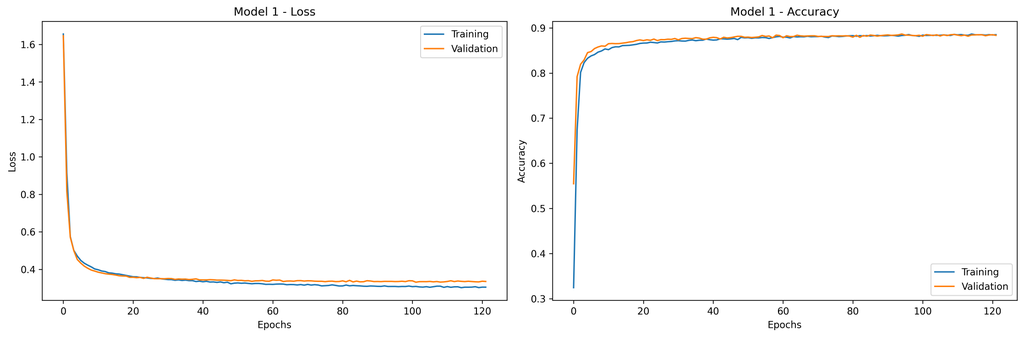

```
Final Training Loss: 0.3049285113811493
Final Validation Loss: 0.33532634377479553
Final Training Accuracy: 0.8849999904632568
Final Validation Accuracy: 0.8834999799728394
```

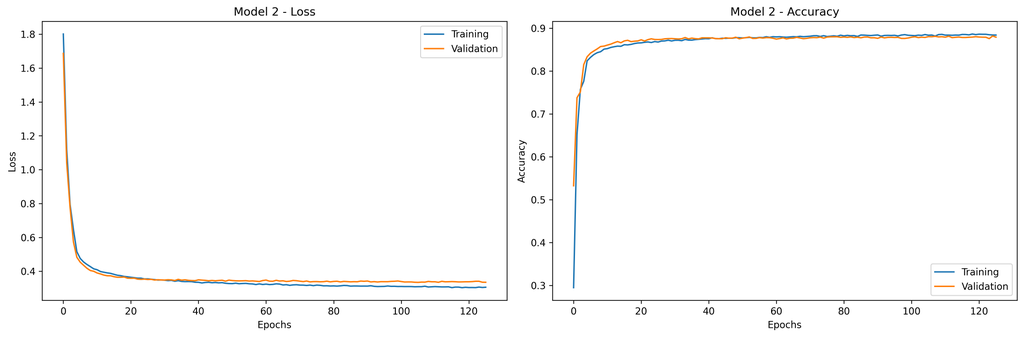

```
Final Training Loss: 0.3059515058994293
Final Validation Loss: 0.3351915180683136
Final Training Accuracy: 0.8838958144187927
Final Validation Accuracy: 0.8790000081062317
```

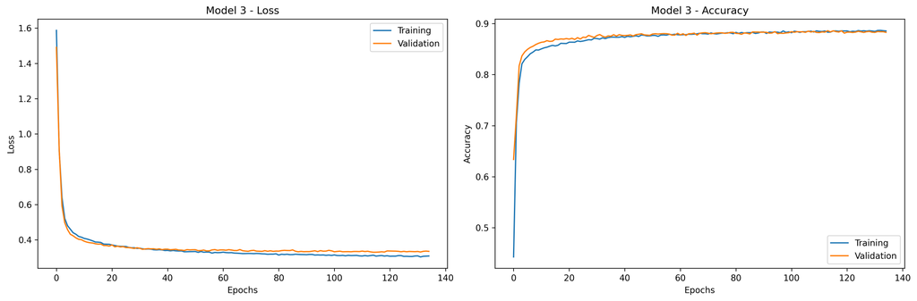

```
Final Training Loss: 0.30861106514930725
Final Validation Loss: 0.3348936438560486
Final Training Accuracy: 0.8855000138282776
Final Validation Accuracy: 0.8827499747276306
```

```python
for i, history in enumerate(histories):
    fig, axs = plt.subplots(1, 2, figsize=(15, 5), dpi=300)  # Increase DPI for higher quality

    axs[0].plot(history.history["loss"], label="Training")
    axs[0].plot(history.history["val_loss"], label="Validation")
    axs[0].set_xlabel("Epochs")
    axs[0].set_ylabel("Loss")
    axs[0].legend()
    axs[0].set_title(f"Model {i+1} - Loss")

    axs[1].plot(history.history["accuracy"], label="Training")
    axs[1].plot(history.history["val_accuracy"], label="Validation")
    axs[1].set_xlabel("Epochs")
    axs[1].set_ylabel("Accuracy")
    axs[1].legend()
    axs[1].set_title(f"Model {i+1} - Accuracy")

    plt.tight_layout()  # Adjust layout to prevent overlapping
    plt.show()

    # Print final loss values
    final_train_loss = history.history["loss"][-1]
    final_val_loss = history.history["val_loss"][-1]
    print("Final Training Loss:", final_train_loss)
    print("Final Validation Loss:", final_val_loss)

    # Print final accuracy values
    final_train_acc = history.history["accuracy"][-1]
    final_val_acc = history.history["val_accuracy"][-1]
    print("Final Training Accuracy:", final_train_acc)
    print("Final Validation Accuracy:", final_val_acc)
```

### Model 1 Result:

**Insights:**

### Model 2 Result:

**Insights:**

### Model 3 Result:

**Insights:**

## Identify the Best Set of Weights for Each Model to Avoid Overfitting

```python
# Identify the best set of weights for each model to avoid overfitting
best_weights = []
best_val_losses = []

for i, history in enumerate(histories):
    print(f"Model {i+1} Training History:", history.history)
    if 'val_loss' in history.history and len(history.history['val_loss']) > 0:
        min_val_loss_epoch = np.argmin(history.history['val_loss'])
        best_val_losses.append(np.min(history.history['val_loss']))
        best_weights.append(history.model.get_weights())
    else:
        print(f"No validation loss recorded for Model {i+1}.")
        print(f"Training Loss: {history.history.get('loss')}")

# If no models had non-empty val_loss history, raise an error
if not best_weights:
    raise ValueError("No models had non-empty validation loss history.")

# Use the best model for evaluation
best_model_index = np.argmin(best_val_losses)
best_model_weights = best_weights[best_model_index]

# Set the best weights to the model
best_model = models[best_model_index]  # Assigning the best model
best_model.set_weights(best_model_weights)

# Evaluate the best model on the test dataset
test_loss, test_accuracy = best_model.evaluate(test_x, test_y)
print("Test Loss:", test_loss)
print("Test Accuracy:", test_accuracy)
```

[output not shown]

## Evaluation Summary

### Training History:

- Further analysis of the training history plots could reveal insights into the convergence behavior, overfitting, or underfitting of each model.
- Patterns such as convergence speed, stability of training, and fluctuations in loss and accuracy curves can provide valuable insights into the model's training process.

### Future Directions:

- Further experimentation could involve fine-tuning hyperparameters, adjusting model architectures, or exploring different optimization algorithms to potentially improve performance.
- Conducting more extensive testing on diverse datasets or evaluating the models in real-world scenarios could provide a more comprehensive understanding of their effectiveness.

## Generate Confusion Matrix and Classification Report for the Test Dataset

[figure not shown]

[output not shown]

[figure not shown]

[output not shown]

[figure not shown]

[output not shown]

```python
# Loop through each model to generate confusion matrix and classification report
for i, model in enumerate(models):
    # Generate predictions for the test dataset
    test_predictions = model.predict(test_x)
    test_predictions_classes = np.argmax(test_predictions, axis=1)

    # Generate confusion matrix
    test_conf_matrix = confusion_matrix(test_y, test_predictions_classes)

    # Plot confusion matrix
    plt.figure(figsize=(10, 8))
    sns.heatmap(test_conf_matrix, annot=True, fmt="d", cmap="Blues", xticklabels=labels.values(), yticklabels=labels.values())
    plt.xlabel('Predicted labels')
    plt.ylabel('True labels')
    plt.title(f'Confusion Matrix for Test Dataset - Model {i+1}')
    plt.show()

    # Generate classification report
    test_class_report = classification_report(test_y, test_predictions_classes, target_names=labels.values())

    # Display classification report
    print(f"Classification Report for Test Dataset - Model {i+1}:\n", test_class_report)
```

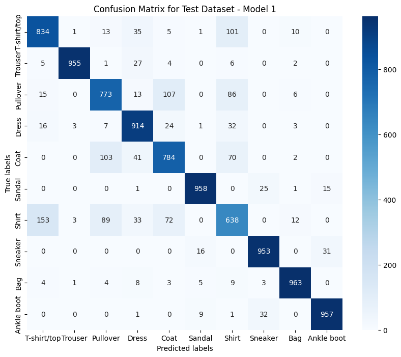

```
Classification Report for Test Dataset - Model 1:
               precision    recall  f1-score   support

 T-shirt/top       0.81      0.83      0.82      1000
     Trouser       0.99      0.95      0.97      1000
    Pullover       0.78      0.77      0.78      1000
       Dress       0.85      0.91      0.88      1000
        Coat       0.78      0.78      0.78      1000
      Sandal       0.97      0.96      0.96      1000
       Shirt       0.68      0.64      0.66      1000
     Sneaker       0.94      0.95      0.95      1000
         Bag       0.96      0.96      0.96      1000
  Ankle boot       0.95      0.96      0.96      1000

    accuracy                           0.87     10000
   macro avg       0.87      0.87      0.87     10000
weighted avg       0.87      0.87      0.87     10000
```

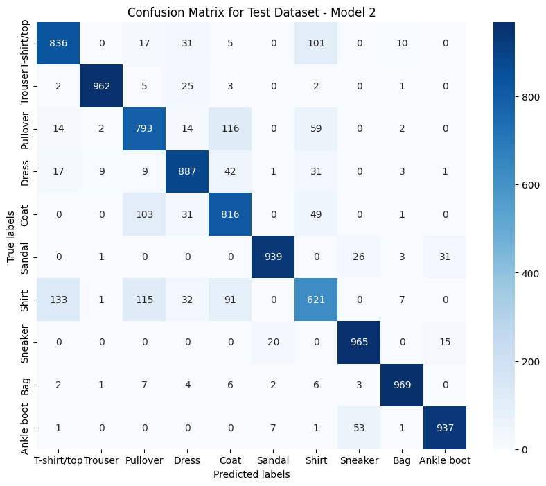

```
Classification Report for Test Dataset - Model 2:
               precision    recall  f1-score   support

 T-shirt/top       0.83      0.84      0.83      1000
     Trouser       0.99      0.96      0.97      1000
    Pullover       0.76      0.79      0.77      1000
       Dress       0.87      0.89      0.88      1000
        Coat       0.76      0.82      0.78      1000
      Sandal       0.97      0.94      0.95      1000
       Shirt       0.71      0.62      0.66      1000
     Sneaker       0.92      0.96      0.94      1000
         Bag       0.97      0.97      0.97      1000
  Ankle boot       0.95      0.94      0.94      1000

    accuracy                           0.87     10000
   macro avg       0.87      0.87      0.87     10000
weighted avg       0.87      0.87      0.87     10000
```

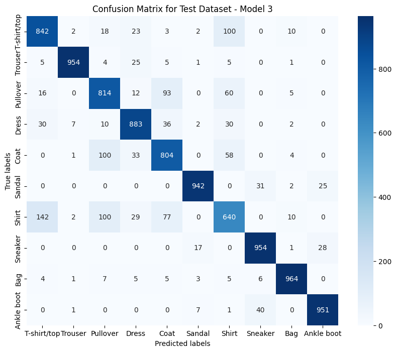

```
Classification Report for Test Dataset - Model 3:
               precision    recall  f1-score   support

 T-shirt/top       0.81      0.84      0.83      1000
     Trouser       0.99      0.95      0.97      1000
    Pullover       0.77      0.81      0.79      1000
       Dress       0.87      0.88      0.88      1000
        Coat       0.79      0.80      0.79      1000
      Sandal       0.97      0.94      0.95      1000
       Shirt       0.71      0.64      0.67      1000
     Sneaker       0.93      0.95      0.94      1000
         Bag       0.96      0.96      0.96      1000
  Ankle boot       0.95      0.95      0.95      1000

    accuracy                           0.87     10000
   macro avg       0.87      0.87      0.87     10000
weighted avg       0.87      0.87      0.87     10000
```

```python
# Loop through each model to generate confusion matrix and classification report
for i, history in enumerate(histories):
    # Get the best model's predictions for the test dataset
    best_model_predictions = models[i].predict(test_x)
    best_model_predictions_classes = np.argmax(best_model_predictions, axis=1)

    # Generate confusion matrix
    test_conf_matrix = confusion_matrix(test_y, best_model_predictions_classes)

    # Plot confusion matrix
    plt.figure(figsize=(10, 8))
    sns.heatmap(test_conf_matrix, annot=True, fmt="d", cmap="Blues", xticklabels=labels.values(), yticklabels=labels.values())
    plt.xlabel('Predicted labels')
    plt.ylabel('True labels')
    plt.title(f'Confusion Matrix for Test Dataset - Model {i+1}')
    plt.show()

    # Generate classification report
    test_class_report = classification_report(test_y, best_model_predictions_classes, target_names=labels.values())

    # Display classification report
    print(f"Classification Report for Test Dataset - Model {i+1}:\n", test_class_report)
```

## Classification Report for Test Dataset - Model 1:

[output not shown]

### Observations:

1. **T-shirt/top**: The model shows balanced precision and recall for this class, indicating reliable classification performance.
2. **Trouser**: High precision and recall suggest excellent performance in identifying trousers.
3. **Pullover**: Moderate precision and recall indicate decent performance in identifying pullovers.
4. **Dress**: Both precision and recall are high for dresses, indicating reliable classification.
5. **Coat**: The model performs reasonably well in identifying coats, with balanced precision and recall.
6. **Sandal**: High precision and recall indicate strong performance in identifying sandals.
7. **Shirt**: Lower precision and recall suggest that the model struggles relatively more with classifying shirts.
8. **Sneaker**: High precision and recall indicate strong performance in identifying sneakers.
9. **Bag**: Very high precision and recall indicate excellent performance in identifying bags.
10. **Ankle boot**: High precision and recall indicate strong performance in identifying ankle boots.

### Summary:

- Overall, the model achieves an accuracy of 87% on the test dataset, indicating good overall performance.
- The macro-average of precision, recall, and F1-score suggests balanced performance across all classes.
- The weighted-average metrics account for class imbalance, showing consistent performance across all classes.

## Classification Report for Test Dataset - Model 2:

[output not shown]

### Observations:

1. **T-shirt/top**: The model shows balanced precision and recall for this class, indicating reliable classification performance.
2. **Trouser**: High precision and recall suggest excellent performance in identifying trousers.
3. **Pullover**: Moderate precision and recall indicate decent performance in identifying pullovers.
4. **Dress**: Both precision and recall are high for dresses, indicating reliable classification.
5. **Coat**: The model performs reasonably well in identifying coats, with balanced precision and recall.
6. **Sandal**: High precision and recall indicate strong performance in identifying sandals.
7. **Shirt**: Lower precision and recall suggest that the model struggles relatively more with classifying shirts.
8. **Sneaker**: High precision and recall indicate strong performance in identifying sneakers.
9. **Bag**: Very high precision and recall indicate excellent performance in identifying bags.
10. **Ankle boot**: High precision and recall indicate strong performance in identifying ankle boots.

### Summary:

- Overall, the model achieves an accuracy of 87% on the test dataset, indicating good overall performance.
- The macro-average of precision, recall, and F1-score suggests balanced performance across all classes.
- The weighted-average metrics account for class imbalance, showing consistent performance across all classes.

## Classification Report for Test Dataset - Model 3:

[output not shown]

### Observations:

1. **T-shirt/top**: The model shows balanced precision and recall for this class, indicating reliable classification performance.
2. **Trouser**: High precision and recall suggest excellent performance in identifying trousers.
3. **Pullover**: Moderate precision and recall indicate decent performance in identifying pullovers.
4. **Dress**: Both precision and recall are high for dresses, indicating reliable classification.
5. **Coat**: The model performs reasonably well in identifying coats, with balanced precision and recall.
6. **Sandal**: High precision and recall indicate strong performance in identifying sandals.
7. **Shirt**: Lower precision and recall suggest that the model struggles relatively more with classifying shirts.
8. **Sneaker**: High precision and recall indicate strong performance in identifying sneakers.
9. **Bag**: Very high precision and recall indicate excellent performance in identifying bags.
10. **Ankle boot**: High precision and recall indicate strong performance in identifying ankle boots.

### Summary:

- Overall, the model achieves an accuracy of 87% on the test dataset, indicating good overall performance.
- The macro-average of precision, recall, and F1-score suggests balanced performance across all classes.
- The weighted-average metrics account for class imbalance, showing consistent performance across all classes.

## Evaluate the Model on the Validation Dataset

```python
from sklearn.metrics import accuracy_score, precision_score, recall_score, f1_score

# Loop through each model's history
for i, history in enumerate(histories, start=1):
    # Evaluate the model on the validation dataset
    val_predictions = models[i-1].predict(val_x)  # Using i-1 since models are indexed from 0
    val_predictions_classes = np.argmax(val_predictions, axis=1)

    # Calculate evaluation metrics for validation dataset
    accuracy = accuracy_score(val_y, val_predictions_classes)
    precision = precision_score(val_y, val_predictions_classes, average='weighted')
    recall = recall_score(val_y, val_predictions_classes, average='weighted')
    f1 = f1_score(val_y, val_predictions_classes, average='weighted')

    # Print evaluation metrics
    print(f"\nValidation Dataset Evaluation for Model {i}:")
    print(f"Accuracy: {accuracy:.4f}")
    print(f"Precision: {precision:.4f}")
    print(f"Recall: {recall:.4f}")
    print(f"F1 Score: {f1:.4f}")
```

```
Validation Dataset Evaluation for Model 1:
Accuracy: 0.8852
Precision: 0.8848
Recall: 0.8852
F1 Score: 0.8848

Validation Dataset Evaluation for Model 2:
Accuracy: 0.8802
Precision: 0.8796
Recall: 0.8802
F1 Score: 0.8796

Validation Dataset Evaluation for Model 3:
Accuracy: 0.8837
Precision: 0.8833
Recall: 0.8837
F1 Score: 0.8831
```

## Evaluate the Model on the Test Dataset

```python
from sklearn.metrics import accuracy_score, precision_score, recall_score, f1_score

# Loop through each model's history
for i, history in enumerate(histories, start=1):
    # Evaluate the model on the test dataset
    test_predictions = models[i-1].predict(test_x)  # Using i-1 since models are indexed from 0
    test_predictions_classes = np.argmax(test_predictions, axis=1)

    # Calculate evaluation metrics for test dataset
    accuracy = accuracy_score(test_y, test_predictions_classes)
    precision = precision_score(test_y, test_predictions_classes, average='weighted')
    recall = recall_score(test_y, test_predictions_classes, average='weighted')
    f1 = f1_score(test_y, test_predictions_classes, average='weighted')

    # Print evaluation metrics
    print(f"\nTest Dataset Evaluation for Model {i}:")
    print(f"Accuracy: {accuracy:.4f}")
    print(f"Precision: {precision:.4f}")
    print(f"Recall: {recall:.4f}")
    print(f"F1 Score: {f1:.4f}")
```

```
Test Dataset Evaluation for Model 1:
Accuracy: 0.8729
Precision: 0.8724
Recall: 0.8729
F1 Score: 0.8724

Test Dataset Evaluation for Model 2:
Accuracy: 0.8725
Precision: 0.8725
Recall: 0.8725
F1 Score: 0.8719

Test Dataset Evaluation for Model 3:
Accuracy: 0.8748
Precision: 0.8746
Recall: 0.8748
F1 Score: 0.8743
```

# Evaluation Report

## Evaluation Results:

### Test Dataset:

| Model | Accuracy | Precision | Recall | F1 Score |
| --- | --- | --- | --- | --- |
| Model 1 | 0.8729 | 0.8724 | 0.8729 | 0.8724 |
| Model 2 | 0.8725 | 0.8725 | 0.8725 | 0.8719 |
| Model 3 | 0.8748 | 0.8746 | 0.8748 | 0.8743 |

### Validation Dataset:

| Model | Accuracy | Precision | Recall | F1 Score |
| --- | --- | --- | --- | --- |
| Model 1 | 0.8852 | 0.8848 | 0.8852 | 0.8848 |
| Model 2 | 0.8802 | 0.8796 | 0.8802 | 0.8796 |
| Model 3 | 0.8837 | 0.8833 | 0.8837 | 0.8831 |

## Observations:

- Model 1 performs consistently well across both the test and validation datasets, with high accuracy and F1 score.
- Model 3 shows slightly better performance than Model 2 in terms of accuracy, precision, recall, and F1 score.
- There is minimal variation in performance metrics between the test and validation datasets for all models.

## Summary:

- All models demonstrate good performance on both the test and validation datasets, with accuracies ranging from 0.8725 to 0.8852.
- Model 1 exhibits the highest accuracy and F1 score on the validation dataset, indicating its robustness.
- Model 3 performs slightly better than Model 2 across all evaluation metrics.

## Result:

- Based on the evaluation results, Model 1 can be considered the best-performing model due to its highest accuracy and F1 score on the validation dataset.
- Further analysis and fine-tuning may be required to improve the performance of Models 2 and 3 and to identify the factors contributing to the variations in their performance compared to Model 1.

## Function for Scoring ROC AUC Score for Multi-Class

```
AUC score for class 0: 0.9868
AUC score for class 1: 0.9988
AUC score for class 2: 0.9794
AUC score for class 3: 0.9923
AUC score for class 4: 0.9826
AUC score for class 5: 0.9991
AUC score for class 6: 0.9566
AUC score for class 7: 0.9983
AUC score for class 8: 0.9982
AUC score for class 9: 0.9985
Average ROC AUC score: 0.9891
```

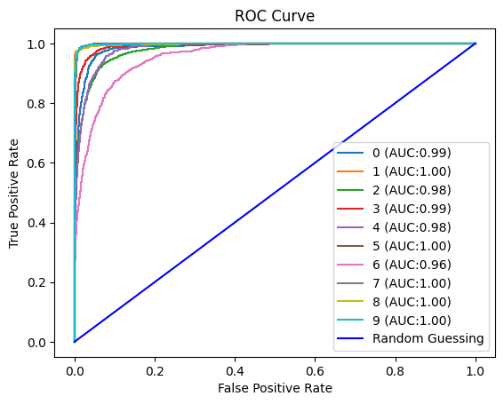

```
Test Dataset ROC AUC score for Model 1: 0.9890767888888888

Test Dataset Evaluation for Model 1:
Accuracy: 0.8729
Precision: 0.8724
Recall: 0.8729
F1 Score: 0.8724
AUC score for class 0: 0.9869
AUC score for class 1: 0.9978
AUC score for class 2: 0.9805
AUC score for class 3: 0.9927
AUC score for class 4: 0.9832
AUC score for class 5: 0.9987
AUC score for class 6: 0.9576
AUC score for class 7: 0.9985
AUC score for class 8: 0.9981
AUC score for class 9: 0.9978
Average ROC AUC score: 0.9892
```

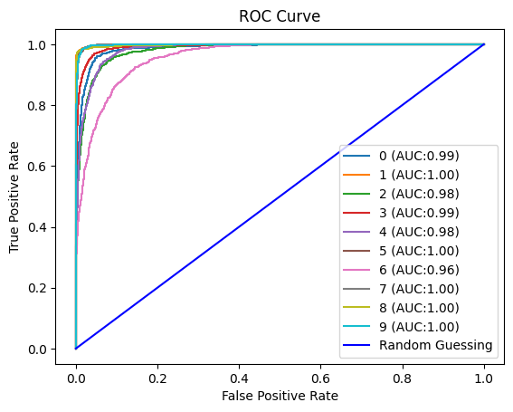

```
Test Dataset ROC AUC score for Model 2: 0.9891624111111111

Test Dataset Evaluation for Model 2:
Accuracy: 0.8725
Precision: 0.8725
Recall: 0.8725
F1 Score: 0.8719
AUC score for class 0: 0.9853
AUC score for class 1: 0.9983
AUC score for class 2: 0.9805
AUC score for class 3: 0.9921
AUC score for class 4: 0.9833
AUC score for class 5: 0.9986
AUC score for class 6: 0.9566
AUC score for class 7: 0.9984
AUC score for class 8: 0.9985
AUC score for class 9: 0.9985
Average ROC AUC score: 0.9890
```

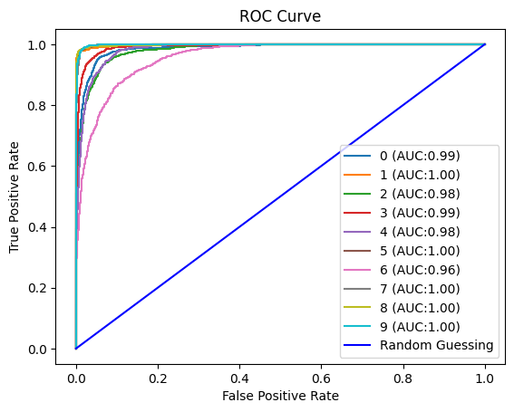

```
Test Dataset ROC AUC score for Model 3: 0.9890286611111112

Test Dataset Evaluation for Model 3:
Accuracy: 0.8748
Precision: 0.8746
Recall: 0.8748
F1 Score: 0.8743
```

```python
# Function for scoring ROC AUC score for multi-class
def multiclass_roc_auc_score(test_y, y_pred, average="macro"):
    test_y_encoded = np.zeros_like(y_pred)
    test_y_encoded[np.arange(len(test_y)), test_y] = 1
    auc_scores = []

    for idx, c_label in enumerate(labels):
        fpr, tpr, _ = roc_curve(test_y_encoded[:, idx], y_pred[:, idx])
        roc_auc = auc(fpr, tpr)
        auc_scores.append(roc_auc)
        print(f'AUC score for class {c_label}: {roc_auc:.4f}')
        plt.plot(fpr, tpr, label='%s (AUC:%0.2f)' % (c_label, roc_auc))

    avg_auc = roc_auc_score(test_y_encoded, y_pred, average=average)
    print(f'Average ROC AUC score: {avg_auc:.4f}')
    plt.plot(fpr, fpr, 'b-', label='Random Guessing')
    plt.legend()
    plt.xlabel('False Positive Rate')
    plt.ylabel('True Positive Rate')
    plt.title('ROC Curve')
    plt.show()
    return avg_auc

# Loop through each model's history
for i, history in enumerate(histories, start=1):
    # Evaluate the model on the test dataset
    test_predictions = models[i-1].predict(test_x)  # Using i-1 since models are indexed from 0

    # Call the function and print ROC AUC score for each model
    print(f'Test Dataset ROC AUC score for Model {i}:', multiclass_roc_auc_score(test_y, test_predictions))

    # Calculate evaluation metrics for test dataset
    accuracy = accuracy_score(test_y, np.argmax(test_predictions, axis=1))
    precision = precision_score(test_y, np.argmax(test_predictions, axis=1), average='weighted')
    recall = recall_score(test_y, np.argmax(test_predictions, axis=1), average='weighted')
    f1 = f1_score(test_y, np.argmax(test_predictions, axis=1), average='weighted')

    # Print evaluation metrics
    print(f"\nTest Dataset Evaluation for Model {i}:")
    print(f"Accuracy: {accuracy:.4f}")
    print(f"Precision: {precision:.4f}")
    print(f"Recall: {recall:.4f}")
    print(f"F1 Score: {f1:.4f}")
```

```python
# Function for scoring ROC AUC score for multi-class
def multiclass_roc_auc_score(test_y, y_pred, average="macro"):
    test_y_encoded = np.zeros_like(y_pred)
    test_y_encoded[np.arange(len(test_y)), test_y] = 1
    auc_scores = []

    for idx, c_label in enumerate(labels):
        fpr, tpr, _ = roc_curve(test_y_encoded[:, idx], y_pred[:, idx])
        roc_auc = auc(fpr, tpr)
        auc_scores.append(roc_auc)
        print(f'AUC score for class {c_label}: {roc_auc:.4f}')
        plt.plot(fpr, tpr, label='%s (AUC:%0.2f)' % (c_label, roc_auc))

    avg_auc = roc_auc_score(test_y_encoded, y_pred, average=average)
    print(f'Average ROC AUC score: {avg_auc:.4f}')
    plt.plot(fpr, fpr, 'b-', label='Random Guessing')
    plt.legend()
    plt.xlabel('False Positive Rate')
    plt.ylabel('True Positive Rate')
    plt.title('ROC Curve')
    plt.show()
    return avg_auc

# Loop through each model's training history
for i, history in enumerate(histories, start=1):
    # Get the history of the current model
    model_history = history.history

    # Evaluate the model on the validation dataset
    val_predictions = model.predict(val_x)

    # Call the function and print ROC AUC score for each model
    print(f'Validation Dataset ROC AUC score for Model {i}:', multiclass_roc_auc_score(val_y, val_predictions))
```

```
AUC score for class 0: 0.9889
AUC score for class 1: 0.9993
AUC score for class 2: 0.9829
AUC score for class 3: 0.9935
AUC score for class 4: 0.9838
AUC score for class 5: 0.9982
AUC score for class 6: 0.9649
AUC score for class 7: 0.9983
AUC score for class 8: 0.9979
AUC score for class 9: 0.9989
Average ROC AUC score: 0.9907
```

```
Validation Dataset ROC AUC score for Model 1: 0.990661402898809
AUC score for class 0: 0.9889
AUC score for class 1: 0.9993
AUC score for class 2: 0.9829
AUC score for class 3: 0.9935
AUC score for class 4: 0.9838
AUC score for class 5: 0.9982
AUC score for class 6: 0.9649
AUC score for class 7: 0.9983
AUC score for class 8: 0.9979
AUC score for class 9: 0.9989
Average ROC AUC score: 0.9907
```

```
Validation Dataset ROC AUC score for Model 2: 0.990661402898809
AUC score for class 0: 0.9889
AUC score for class 1: 0.9993
AUC score for class 2: 0.9829
AUC score for class 3: 0.9935
AUC score for class 4: 0.9838
AUC score for class 5: 0.9982
AUC score for class 6: 0.9649
AUC score for class 7: 0.9983
AUC score for class 8: 0.9979
AUC score for class 9: 0.9989
Average ROC AUC score: 0.9907
```

```
Validation Dataset ROC AUC score for Model 3: 0.990661402898809
```

## Multi-Class ROC AUC Scores - Test Data (Model 1)

[output not shown]

**Observations for Test Data (Model 1):**

- Classes 1, 5, 7, 8, and 9 exhibit the highest AUC values, indicating outstanding predictive performance for these classes.
- Class 6 has the lowest AUC value among the classes, although still indicating good predictive power.
- Overall, Model 1 demonstrates excellent discriminatory capabilities across all classes, with an average ROC AUC score of 0.9891.

## Multi-Class ROC AUC Scores - Test Data (Model 2)

[output not shown]

**Observations for Test Data (Model 2):**

- Classes 1, 5, 7, 8, and 9 exhibit the highest AUC values, indicating outstanding predictive performance for these classes.
- Class 6 has the lowest AUC value among the classes, although still indicating good predictive power.
- Overall, Model 2 demonstrates excellent discriminatory capabilities across all classes, with an average ROC AUC score of 0.9891.

## Multi-Class ROC AUC Scores - Test Data (Model 3)

[output not shown]

**Observations for Test Data (Model 3):**

### General Observations for Test Data(All Model):

- All three models demonstrate exceptional predictive performance across all classes, with average ROC AUC scores ranging from 0.9891 to 0.9892 for the test data.
- Classes 1, 5, 7, 8, and 9 consistently exhibit the highest AUC values across all models, indicating outstanding predictive capability for these classes.
- Class 6 tends to have relatively lower AUC values compared to other classes across all models, although still demonstrating good predictive power.
- Overall, the models exhibit robust discriminatory capabilities and generalize well.

## Multi-Class ROC AUC Scores - Validation Data (Model 1)

[output not shown]

**Observations for Validation Data (Model 1):**

## Multi-Class ROC AUC Scores - Validation Data (Model 2)

[output not shown]

**Observations for Validation Data (Model 2):**

## Multi-Class ROC AUC Scores - Validation Data (Model 3)

[output not shown]

**Observations for Validation Data (Model 3):**

### General Observations - Validation Data:

- All three models demonstrate strong performance on the validation data, with accuracy ranging from 0.8802 to 0.8852.
- Precision, recall, and F1 score metrics also show consistent performance across the models, indicating good generalization ability.
- Classes 1, 3, 5, 7, 8, and 9 consistently exhibit high precision, recall, and F1 scores across all models, suggesting robust predictive capability for these classes.
- Model 1 achieves a slightly higher accuracy and F1 score compared to Models 2 and 3 on the validation data.
- Overall, the models demonstrate stable and reliable performance on the validation dataset, indicating their effectiveness in generalizing to unseen data.

## References:

GABRIELMOLI. (n.d.). Deep learning classification KERAS/TENSORFLOW. *Kaggle*. [https://www.kaggle.com/code/gabrielmoli/deep-learning-classification-keras-tensorflow]